# math250_nov5_ArleneMedina

# Problem 1

## The first two problems in this set refer to the ISLR2::Carseats set, which includes simulated sample data for 400 stores selling a particular brand of child carseat. We view this data as a simple random sample from a larger population.

## Does this data provide evidence against the company’s claim that the average price of their own seats is $110? Follow all best practices from class, including hypotheses, a relevant visualization, and a conclusion in non-technical language.

```r
library(ISLR2)
library(tidyverse)
glimpse(Carseats$Price)
```

```
 num [1:400] 120 83 80 97 128 72 108 120 124 124 ...
```

## Hypthesis: From just taking a quick glance at it’s 400 rows and 11 respective columns. I would say that the average price of the carseats is more than $110 per seat. As well as from past/real life situations.

```r
summary(Carseats$Price)
```

```
   Min. 1st Qu.  Median    Mean 3rd Qu.    Max.
   24.0   100.0   117.0   115.8   131.0   191.0
```

## Visualization that supports output of summary:

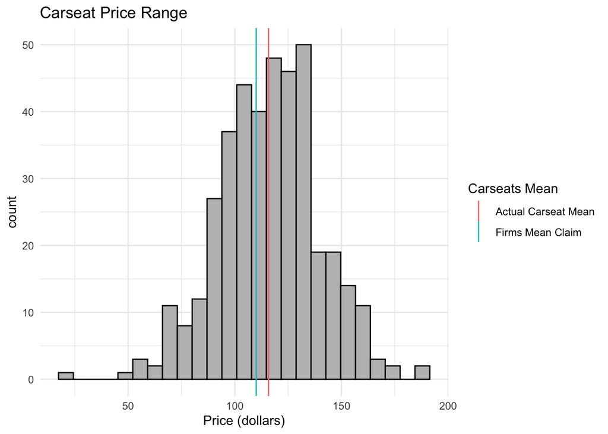

```r
ggplot(Carseats,aes(x = Price)) +
  geom_histogram(color = "black",
                 fill = "grey",
                 bins = 25) + #so that the message error could be removed
  geom_vline(aes(xintercept = 115.8, #previously mentioned in
             color = "Actual Carseat Mean"))+
  geom_vline(aes(xintercept = 110, #previously mentioned in
             color = "Firms Mean Claim"))+
  labs(title = "Carseat Price Range",
       x = "Price (dollars)",
       color = "Carseats Mean") +
  theme_minimal()
```

## Conclusion (non-technical language): We can determine that the firms carseats average is more than what they claim it to be. Meaning that the carseats are on average more expensive than $110 that they claim. Instead they’re 115.8.

# Problem 2:

## Compute a level 90% confidence interval for the mean competitor price in the population from which this sample is drawn. What is the sample mean? What is the margin of error?

```r
mean_competition_price <- mean(Carseats$CompPrice) #Learned from Professors vid "Confidence Intervals in R"
new_t_test <- t.test(Carseats$CompPrice, conf.level = .90)
new_t_test #From the output we learned: 126.2391 - 124.975
```

```
    One Sample t-test

data:  Carseats$CompPrice
t = 163, df = 399, p-value < 2.2e-16
alternative hypothesis: true mean is not equal to 0
90 percent confidence interval:
 123.7109 126.2391
sample estimates:
mean of x
  124.975
```

## The Marginal Error is: 1.2641

## The Sample Mean is : 124.975

# Problem 3: Create a table with counts of penguin species and home islands in the penguins set. Include marginal counts in the table.

```r
t <- table(penguins$species, penguins$island)
t
```

```
            Biscoe Dream Torgersen
  Adelie        44    56        52
  Chinstrap      0    68         0
  Gentoo       124     0         0
```

```r
addmargins(t) #Adding marginal counts
```

```
            Biscoe Dream Torgersen Sum
  Adelie        44    56        52 152
  Chinstrap      0    68         0  68
  Gentoo       124     0         0 124
  Sum          168   124        52 344
```

# Problem 4: Push solution to Github page, including both both the Quarto Source and the rendered html. Use file names of the form, and provide clickable link.